# projet_final

## 1. Acquisition et chargement des données

```python
import pandas as pd
import numpy as np
import requests as r
from bs4 import BeautifulSoup
from collections import defaultdict
from shutil import copyfileobj
from urllib import request
import matplotlib.pyplot as plt
import seaborn as sns
```

- Acquérir l'ensemble des fichiers Excel des classements via la page de classement.

(Je suppose que je n'ai eu aucun problème pour cette partie en simulant le code qui devait être fait pour rapatrier tous les fichiers).

```python
### JE SUPPOSE QUE JE N'AVAIS PAS DE PROBLEME - VOICI LE CODE QUE J'AURAI EFFECTUÉ #####

request = r.get('https://www.vendeeglobe.org/fr/classement')
bs = BeautifulSoup(request.content)
test = bs.findAll('option')
all_ranks = [elem.attrs['value'] for elem in test][1:]

for k, rank in enumerate(all_ranks):
    url = 'https://www.vendeeglobe.org/download-race-data/vendeeglobe_'+rank+'.xlsx'
    filename = f'exemple_{k}.xlsx'

    with request.urlopen(url) as response, open(filename, 'wb') as out_file:
        copyfileobj(response, out_file)

# Puis il faut maintenant concatener tout les fichiers que l'on va lire

dataframes = []

for i in range(485):
    dataframes.append(pd.read_excel('exemple'+i+'.xlsx'))

df_final = pd.concat(dataframes)

df_final.to_csv('df_final')
```

```python
df = pd.read_csv('df_final.csv') # Fichier CSV comportant tout les dataframes brut concaténer fournis par Hippolyte (j'ai quand même simulé le code ci-dessus)
df.head(4)
```

|  | Unnamed: 0 | Unnamed: 0.1 | Unnamed: 1 | Unnamed: 2 | Unnamed: 3 | Unnamed: 4 | Unnamed: 5 | Unnamed: 6 | Unnamed: 7 | Unnamed: 8 | ... | Unnamed: 11 | Unnamed: 12 | Unnamed: 13 | Unnamed: 14 | Unnamed: 15 | Unnamed: 16 | Unnamed: 17 | Unnamed: 18 | Unnamed: 19 | Unnamed: 20 |
| --- | --- | --- | --- | --- | --- | --- | --- | --- | --- | --- | --- | --- | --- | --- | --- | --- | --- | --- | --- | --- | --- |
| 0 | 0 | NaN | NaN | NaN | NaN | NaN | NaN | NaN | NaN | NaN | ... | NaN | NaN | NaN | NaN | NaN | NaN | NaN | NaN | NaN | NaN |
| 1 | 1 | NaN | Classement du mercredi 27 janvier 2021 à 15h00 FR | NaN | NaN | NaN | NaN | NaN | NaN | NaN | ... | NaN | NaN | NaN | NaN | NaN | NaN | NaN | NaN | NaN | NaN |
| 2 | 2 | NaN | Rang\nRank | Nat. / Voile\nNat. / Sail | Skipper / Bateau\nSkipper / crew | NaN | NaN | NaN | Depuis 30 minutes\nSince 30 minutes | NaN | ... | Depuis le dernier classement\nSince the the la... | NaN | NaN | NaN | Depuis 24 heures\nSince 24 hours | NaN | NaN | NaN | DTF | DTL |
| 3 | 3 | NaN | NaN | NaN | NaN | Heure FR\nHour FR | Latitude\nLatitude | Longitude\nLongitude | Cap\nHeading | Vitesse\nSpeed | ... | Cap\nHeading | Vitesse\nSpeed | VMG\nVMG | Distance\nDistance | Cap\nHeading | Vitesse\nSpeed | VMG\nVMG | Distance\nDistance | NaN | NaN |

4 rows × 22 columns

## 2. Préparation des données

```python
def dms2dec(deg, mn, sec):
    """Longitude / Latitude en format décimal"""
    return deg + mn / 60 + sec / 3600

def extract(df, columns):
    """ Extraction des données numériques """
    for col in columns:
        df[col] = df[col].str.extract('(\d+(?:\.\d+)?)')

def cleaning_step(df):

    df = df.iloc[2:-4].copy()
    df.drop(columns = df.columns[:2], axis = 0, inplace = True)
    old_cols = df.columns[3: -2]
    new_cols = df.iloc[1].dropna().to_list()
    df.rename(columns={old:new for old,new in zip(old_cols, new_cols)}, inplace = True)

    old_cols_2 = df.columns[:3].to_list() + df.columns[-2:].to_list()
    new_cols_2 = df.iloc[0][:3].to_list() + df.iloc[0][-2:].to_list()
    df.rename(columns={old:new for old,new in zip(old_cols_2, new_cols_2)}, inplace = True)

    df.rename(columns={elem:elem.split('\n')[0] for elem in df.columns[:-2]}, inplace = True)
    df.columns = [elem+'_'+str(k) for k,elem in enumerate(df.columns)]
    premieres_cols = df.columns[:6]
    d_dc = df.columns[10:14]
    d_30m = df.columns[6:10]
    d_24h = df.columns[14:-2]
    dtf_dtl = df.columns[-2:]
    df.rename(columns={elem : elem.split('_')[0] + '_d_der_class' for elem in d_dc}, inplace = True)
    df.rename(columns={elem : elem.split('_')[0] + '_d_30min' for elem in d_30m}, inplace = True)
    df.rename(columns={elem : elem.split('_')[0] + '_d_24h' for elem in d_24h}, inplace = True)
    df.rename(columns={elem : elem.split('_')[0] for elem in premieres_cols}, inplace = True)
    df.rename(columns={elem : elem.split('_')[0] for elem in dtf_dtl}, inplace = True)
    df.dropna(axis = 0, inplace = True)

    df['Skipper'] = df['Skipper / Bateau'].apply(lambda x: x.split('\n')[0])
    df['Bateau'] = df['Skipper / Bateau'].apply(lambda x: x.split('\n')[1])
    df = df.apply(lambda x: x.str.replace('\n', ' '))
    df.rename(columns={'Nat. / Voile' : 'Num_voile'}, inplace = True)
    df.drop(columns = ['Skipper / Bateau'], inplace = True)

    reorder_cols = df.columns.to_list()[:2] + df.columns.to_list()[-2:] + df.columns.to_list()[2:-2]
    df = df[reorder_cols]

    df['deg_lat'] = df['Latitude'].apply(lambda x: x.split('°')[0]).astype(float)
    df['min_lat'] = df['Latitude'].apply(lambda x: x.split('°')[1].split('.')[0]).astype(float)
    df['sec_lat'] = df['Latitude'].apply(lambda x: x.split('°')[1].split('.')[1].split("'")[0]).astype(float)

    df['deg_long'] = df['Longitude'].apply(lambda x: x.split('°')[0]).astype(float)
    df['min_long'] = df['Longitude'].apply(lambda x: x.split('°')[1].split('.')[0]).astype(float)
    df['sec_long'] = df['Longitude'].apply(lambda x: x.split('°')[1].split('.')[1].split("'")[0]).astype(float)

    df['Latitude_dec'] = dms2dec(df['deg_lat'], df['min_lat'], df['sec_lat'])
    df['Longitude_dec'] = dms2dec(df['deg_long'], df['min_long'], df['sec_long'])

    df.drop(columns=['deg_long', 'min_long', 'sec_long', 'deg_lat', 'min_lat', 'sec_lat', 'Latitude', 'Longitude'], inplace = True)

    reorder_cols = df.columns.to_list()[:5] + df.columns.to_list()[-2:] + df.columns.to_list()[5:-2]
    df['Num_voile'] = df['Num_voile'].str.strip()
    df = df[reorder_cols]

    cols = df.columns[7:]
    extract(df = df, columns= cols)

    return df

def df_features_boats():

    """ Retourne un Dataframe regroupant les caractéristiques de chaque bateau """
    carac_bat = defaultdict(list)
    request = r.get('https://www.vendeeglobe.org/fr/glossaire')
    bs = BeautifulSoup(request.content)
    nom_bateaux = bs.findAll('h3', attrs={'class' : 'boats-list__popup-title'})
    glossary = bs.findAll('ul', attrs={'class' : 'boats-list__popup-specs-list'})
    y = False
    carac_pertinentes= ['Numéro de voile', 'Longueur',  'Largeur', "Tirant d'eau", 'Déplacement (poids)', 'Nombre de dérives', 'Hauteur mât', 'Surface de voiles au près', 'Surface de voiles au portant']

    for tag, nom_bat in zip(glossary, nom_bateaux):

        if nom_bat.text == 'LinkedOut':
            y = True
        if nom_bat.text != '':
            carac_bat['Bateau'].append(nom_bat.text)

        for tag_li in tag.findAll('li'):
            l = tag_li.text.split(':')
            key = l[0].strip()
            val = l[1].strip()
            if key in carac_pertinentes:
                carac_bat[key].append(val)
            if y == True:
                carac_bat['Numéro de voile'].append('FRA 59')
            y = False

    dic_carac_bat = dict(carac_bat)
    feat_bat = pd.DataFrame(dic_carac_bat)
    cols = feat_bat.columns[1:5].to_list() + feat_bat.columns[6:].to_list()
    feat_bat = feat_bat.apply(lambda x: x.str.replace(',', '.'))
    cols = feat_bat.columns[2:6].to_list() + feat_bat.columns[7:].to_list()
    extract(df = feat_bat, columns = cols)

    feat_bat[['test1', 'test2']] = feat_bat['Numéro de voile'].str.extract('([a-zA-Z ]*)(\d+)')
    feat_bat['test1'] = feat_bat['test1'].str.strip()
    feat_bat['test2'] = feat_bat['test2'].str.strip()
    feat_bat['Num_voile'] = feat_bat['test1'].str.cat(feat_bat['test2'], sep = ' ')
    feat_bat.drop(columns=['test1', 'test2', 'Numéro de voile'], inplace = True)
    feat_bat = feat_bat[[feat_bat.columns[-1]] + feat_bat.columns[:-1].to_list()]

    feat_bat['Déplacement (poids)'] = feat_bat['Déplacement (poids)'].interpolate()
    cols_num = feat_bat.columns[2:6].to_list() + feat_bat.columns[7:].to_list()
    feat_bat[cols_num] = feat_bat[cols_num].astype(float)
    feat_bat['Num_voile'] = feat_bat['Num_voile'].str.strip()

    return feat_bat
```

```python
df = cleaning_step(df)
df.head(3)
```

|  | Rang | Num_voile | Skipper | Bateau | Heure FR | Latitude_dec | Longitude_dec | Cap_d_30min | Vitesse_d_30min | VMG_d_30min | ... | Cap_d_der_class | Vitesse_d_der_class | VMG_d_der_class | Distance_d_der_class | Cap_d_24h | Vitesse_d_24h | VMG_d_24h | Distance_d_24h | DTF | DTL |
| --- | --- | --- | --- | --- | --- | --- | --- | --- | --- | --- | --- | --- | --- | --- | --- | --- | --- | --- | --- | --- | --- |
| 4 | 1 | FRA 79 | Charlie Dalin | APIVIA | 14:30 FR | 46.235278 | 3.700278 | 39 | 21.0 | 16.0 | ... | 37 | 19.1 | 17.4 | 57.2 | 61 | 13.9 | 13.9 | 334.3 | 80.5 | 0.0 |
| 5 | 2 | FRA 18 | Louis Burton | Bureau Vallée 2 | 14:31 FR 1min | 46.417222 | 5.208333 | 116 | 17.8 | 15.6 | ... | 110 | 17.7 | 16.9 | 53.3 | 100 | 17.2 | 16.9 | 412.1 | 141.5 | 60.9 |
| 6 | 3 | MON 10 | Boris Herrmann | Seaexplorer - Yacht Club De Monaco | 14:30 FR | 44.529444 | 5.348611 | 130 | 18.2 | 3.4 | ... | 113 | 16.6 | 10.3 | 49.9 | 84 | 13.5 | 12.9 | 323.5 | 190.0 | 109.5 |

3 rows × 21 columns

- Acquérir les caractéristiques des bateaux.

```python
df_features = df_features_boats()
df_features.head(3)
```

|  | Num_voile | Bateau | Longueur | Largeur | Tirant d'eau | Déplacement (poids) | Nombre de dérives | Hauteur mât | Surface de voiles au près | Surface de voiles au portant |
| --- | --- | --- | --- | --- | --- | --- | --- | --- | --- | --- |
| 0 | FRA 56 | NEWREST - ART & FENÊTRES | 18.28 | 5.85 | 4.5 | 7.0 | foils | 29.0 | 320.0 | 570.0 |
| 1 | FRA 49 | PURE - Best Western® | 18.28 | 5.80 | 4.5 | 9.0 | 2 | 28.0 | 280.0 | 560.0 |
| 2 | FRA 72 | TSE - 4MYPLANET | 18.28 | 5.54 | 4.5 | 9.0 | 2 | 29.0 | 260.0 | 580.0 |

La colonne Déplacement (poids) comportait quelques NaN. Cependant, en observant la courbe (ci-dessous) il semblait judicieux de faire une interpolation linéaire au lieu de perdre de l'information.

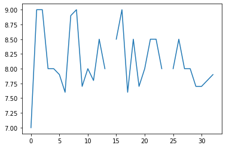

```python
df_features['Déplacement (poids)'].plot()
plt.show()
```

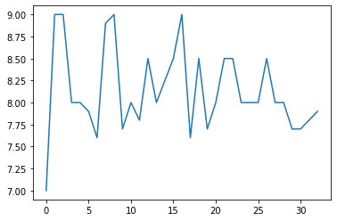

```python
df_features['Déplacement (poids)'].astype(float).interpolate().plot()
plt.show()
```

```python
df_features['Déplacement (poids)'] = df_features['Déplacement (poids)'].astype(float).interpolate()
```

À ce stade, nous avons donc notre dataframe de départ nettoyé avec un autre dataframe comportant les caractéristiques de chacun des voiliers.

En fonction de la problématique à résoudre, ou bien de ce que l'on souhaite observer, on fera un merge de notre dataframe principal (df), avec les caractéristiques de l'autre dataframe (df_features) qui nous interèssent grâce à la colonne qui fera office de clé de jointure : *Num_voile*

## 3. Analyses et story telling

```python
cols = [df.columns[0]] + df.columns[5:].to_list() # Convertir en float les données numériques
df[cols] = df[cols].astype(float)
```

- Corrélation entre le classement (rang) et la vitesse utile (VMG) des voiliers.

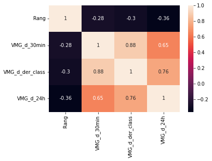

```python
q13 = df[['Rang', 'VMG_d_30min', 'VMG_d_der_class', 'VMG_d_24h']]
sns.heatmap(q13.corr(), annot=True)
plt.show()
```

Comme nous pouvons le constater, il ne semble pas y avoir une forte corrélation entre la vitesse utile des voiliers et le classement. Essayons d'avoir une meilleure interprétation à travers un graphique.

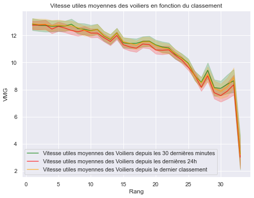

```python
sns.set_theme()
plt.figure(figsize=(8,6))
sns.lineplot(x = df['Rang'], y = df['VMG_d_30min'], label = 'Vitesse utiles moyennes des Voiliers depuis les 30 dernières minutes', c = 'green', alpha = 0.7)
sns.lineplot(x = df['Rang'], y = df['VMG_d_24h'], label = 'Vitesse utiles moyennes des Voiliers depuis les dernières 24h', c = 'red', alpha = 0.7)
sns.lineplot(x = df['Rang'], y = df['VMG_d_der_class'], label = 'Vitesse utiles moyennes des Voiliers depuis le dernier classement', c = 'orange',  alpha = 0.7)
plt.ylabel('VMG')
plt.title('Vitesse utiles moyennes des voiliers en fonction du classement')
plt.show()
```

Nous pourrions penser que, si les skipper connaissents leur rang, cela a plus d'impact sur les premiers et donnent tout pour conserver leur rang.

D'autres facteurs que l'humain doivent sûrement jouer.

En effet, certaines caractéristiques bateaux sont peut-être plus avantageuses que d'autres, ce qui pourrait expliquer en partie la différence de vitesse que l'on observe entre les skippers.

- Impact de la présence d'un foil sur le classement et la vitesse des voiliers.

D'après plusieurs recherches, les foils permettent de se déplacer plus rapidement. Sans eux, il y a beaucoup plus de résistance sur la coque et donc moins de vitesse. Il sont donc utilisés pour minimiser la résistance et augmenter la vitesse.

D'après les informations que nous avons à disposition, déterminons tout d'abord l'impact d'un foil sur la vitesse. Pour l'analyse que nous souhaitons faire, il est néccéssaire de croiser l'information 'nombre de dérives' avec notre premier Dataset.

De plus, nous avons besoin que de quelques colonnes dans notre dataframe initial pour cette analyse : les 3 vitesses (30 min avant, 24h avant, depuis le dernier classement) et le rang (pour l'impact des foils sur le ranking par la suite).

```python
df2 = df[['Rang', 'Num_voile', 'Vitesse_d_30min', 'Vitesse_d_24h', 'Vitesse_d_der_class']].copy()
dff2 = df_features[['Num_voile', 'Nombre de dérives']].copy()
```

Il était neccessaire de faire certaines manipulations sur la colonne Num_voile du dataframe dff2 (df_features) afin d'avoir un merge conhérent avec df2 (df).

```python
num_voil_dict = {'17' : 'FRA 17', '08' : 'FRA 8', '18' : 'FRA 18', '69' : 'FR FRA 69', '001' : 'FRA 01', '4' : 'FRA 4', '2' : 'FR FRA 02', 'GBR 77' : 'GBR 777', '16' : 'MON 10', 'SUI 07' : 'SUI 7'}
dff2['Num_voile'] = dff2['Num_voile'].apply(lambda x: num_voil_dict.get(x, x))
merge = df2.merge(dff2, on = "Num_voile", how = 'left')
merge.head(3)
```

|  | Rang | Num_voile | Vitesse_d_30min | Vitesse_d_24h | Vitesse_d_der_class | Nombre de dérives |
| --- | --- | --- | --- | --- | --- | --- |
| 0 | 1.0 | FRA 79 | 21.0 | 13.9 | 19.1 | foils |
| 1 | 2.0 | FRA 18 | 17.8 | 17.2 | 17.7 | foils |
| 2 | 3.0 | MON 10 | 18.2 | 13.5 | 16.6 | foils |

Puisque l'objectif ici était principalement de visualiser l'impact de la vitesse, avec ou sans foils, la colonne nombre de dérive a été modifiée afin d'avoir un visuel plus compréhensif : *Sans foil* | *Avec foils*

```python
dic = {'foils' : 'Avec foils', 'foiler' : 'Avec foils', '2' : 'Sans foils', '2 asymétriques' : 'Sans foils'} # Meilleur compréhension sur les prochain graphiques qui vont être produit
merge['Nombre de dérives'] = merge['Nombre de dérives'].apply(lambda x: dic.get(x, x))
merge['Nombre de dérives'].value_counts()
```

```
Avec foils    7059
Sans foils    6725
Name: Nombre de dérives, dtype: int64
```

Nous allons moyenner les 3 vitesses (30 min avant, 24h avant, depuis le dernier classement) pour avoir un aperçu sur le comportement général de la vitesse avec ou sans foils.

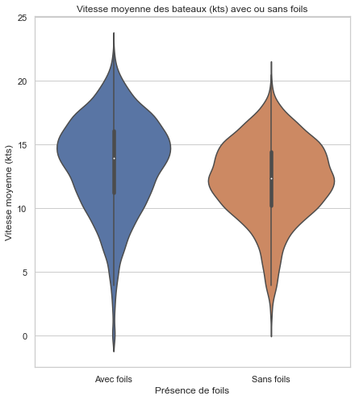

```python
sns.set_theme(style="whitegrid")
merge['Vitesse_moy'] = (merge['Vitesse_d_30min'] + merge['Vitesse_d_24h'] + merge['Vitesse_d_der_class']) / 3
test = merge.groupby('Nombre de dérives')['Vitesse_moy'].agg(np.mean).reset_index()

plt.figure(figsize=(7,8))
sns.violinplot(data = merge, x = 'Nombre de dérives', y = 'Vitesse_moy')
plt.ylabel('Vitesse moyenne (kts)')
plt.xlabel('Présence de foils')
plt.title('Vitesse moyenne des bateaux (kts) avec ou sans foils')
plt.show()
```

Comme nous pouvons l'observer ci-dessus, la présence d'un foil sur le bateau semble en moyenne augmenter légèrement la vitesse des bateaux.

Au vu de ces résultats, nous pourrions peut-être nous attendre à voir généralement des skippers (bateaux avec foils) sur le haut du tableau.

Analysons le pourcentage de skippers équipés de foils pour chaque rang dans le classement.

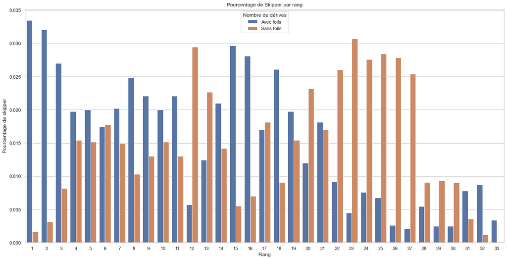

```python
t = merge[['Rang', 'Nombre de dérives']].value_counts(normalize = True).reset_index()
t['Rang'] = t['Rang'].astype(int)
t.rename(columns={0 : 'Pourcentage de skipper'}, inplace=True)

plt.figure(figsize=(20,10))
sns.barplot(data = t, x = 'Rang', y = 'Pourcentage de skipper', hue = 'Nombre de dérives')

plt.ylabel('Pourcentage de skipper')
plt.xlabel('Rang')
plt.title('Pourcentage de Skipper par rang')
plt.show()
```

Nous pouvons observer que le pourcentage de skippers sans foil est plus prononcé entre les places 22 et 27.

A contrario, nous avons un pourcentage plus élevé de skippers avec des foils sur les premières places.

Cela semble cohérent, si cela donne un avantage sur la vitesse des voiliers, on s'attend vraisemblablement à trouver dans le top des skippers équipés de foils.

- Visualisation de la distance parcourue par voilier.

Pour récupérer la distance totale parcourue par chaque voilier, nous allons prendre la somme des distances parcourues en prenant comme interval chaque classement.

On utilisera donc la colonne : *Distance_d_der_class*

```python
df['Distance_d_der_class'].head(3)
```

```
4    57.2
5    53.3
6    49.9
Name: Distance_d_der_class, dtype: float64
```

Commençons tout d'abord à convertir cette distance (Mille marin) en kilomètres. Pour l'analyse que l'on souhaite faire, notre premier dataframe (df) suffit.

```python
df['Distance_d_der_class'] = df['Distance_d_der_class'] * 1.852

df['Distance_d_der_class'].head(3)
```

```
4    105.9344
5     98.7116
6     92.4148
Name: Distance_d_der_class, dtype: float64
```

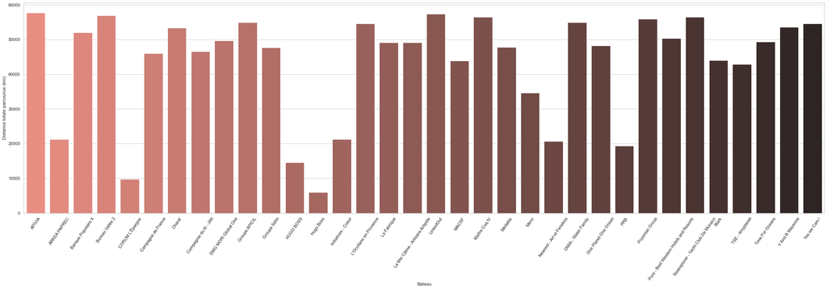

```python
# On somme dès à présent la distance parcouru Distance_d_der_class de chaque skipper grâce au group by sur le bateau
dist_df = df.groupby(['Bateau'])['Distance_d_der_class'].sum().reset_index()
plt.figure(figsize=(37,10))
ax = sns.barplot(data = dist_df, x = 'Bateau', y = 'Distance_d_der_class', palette= 'dark:salmon_r')
plt.xticks(rotation=55)
plt.ylabel('Distance totale parcourue (km)')
plt.show()
```

Nous remarquons qu'il y a plusieurs distances assez courtes, certains skippers semblent ne pas avoir terminé la course. D'après le lien suivant : https://www.vendeeglobe.org/fr/cartographie, si nous scrollons tout en bas, nous observons que les skippers ci-dessous ont abandonné :

- Merci
- MACSF
- Newrest-Art et Fenetres
- initivatives-Coeur
- Arkea paprec
- hugo boss
- prb
- corum l'épargne